# Predicting Graduate Admissions with Support Vector Machine (SVM) and Gradient Boosting using XGBoost

ADELIYI OLUTOMIWA

# 1.0 INTRODUCTION

This report presents a study on the admission data of prospective students, aiming to predict the likelihood of their acceptance into a university. The dataset obtained from [kaggle] (https://www.kaggle.com/datasets/mohansacharya/graduate-admissions) contains various attributes, including `GRE and TOEFL scores`, `Statements of Purpose (SOP)`, `Letters of Recommendation (LOR)`, `Cumulative Grade Point Average (CGPA)`, and `the chance of admission`.

The analysis begins with exploratory data analysis (EDA), where we investigate the relationships between the variables and their distributions. We also visualize the influence of factors such as `University Rating` and `Research` on the admission process. The main goal is to identify patterns and insights that may help improve the prediction models.

For modeling, two different approaches are explored: `Support Vector Machine (SVM)` and `Gradient Boosting using XGBoost`. SVM is employed as a powerful classification algorithm that works well for both linear and non-linear relationships. On the other hand, XGBoost, a popular boosting technique, is utilized to handle complex interactions and improve predictive accuracy.

To evaluate the performance of the models, we use Receiver Operating Characteristic Area Under the Curve (ROC AUC), a metric that assesses the ability of the models to distinguish between accepted and rejected applicants.

Let’s proceed with a detailed analysis and interpretation of the results obtained from the SVM and XGBoost models.

# 2.0 METHODOLOGY

The methodology followed in this study involves several key steps to predict the likelihood of admission for prospective students. The initial phase revolves around data pre-processing, where the admission dataset is loaded and its structure is examined. To facilitate analysis, the `University Rating` column is transformed into a factor. Additionally, numeric attributes, such as `GRE Score`, `TOEFL Score`, `SOP`, `LOR`, and `CGPA`, are scaled to ensure their comparability.

The subsequent step involves exploratory data analysis (EDA) to gain insights into the dataset. The distribution of the “Chance of Admission” variable is visualized to understand its spread and potential patterns. Scatter plots are generated to explore the relationships between the numeric variables `(GRE Score, TOEFL Score, SOP, LOR, CGPA)` and the `Chance of Admission`. Furthermore, a correlation plot is constructed to examine the interrelationships between the numeric attributes, identifying potential correlations that may influence the admission outcome.

To evaluate the performance of predictive models, the dataset is split into a training set (90%) and a test set (10%) using the `caret` package. The training set will be utilized to train the models, while the test set will serve for model evaluation. Two different approaches are explored for modeling: Support Vector Machine (SVM) and Gradient Boosting using XGBoost. SVM, known for its ability to handle both linear and non-linear relationships, is employed to create the initial model. On the other hand, XGBoost, a powerful boosting technique, is utilized to capture complex interactions and enhance predictive accuracy

# 3.0 EXPLORATORY DATA ANALYSIS

The Exploratory Data Analysis (EDA) section of this study focuses on gaining a comprehensive understanding of the admission dataset and identifying potential patterns and relationships among its variables. The primary goal is to explore the data visually and statistically, providing valuable insights to guide the subsequent modeling process.

```r
knitr::opts_chunk$set(echo = TRUE)
library(tidyverse)
library(e1071)
library(xgboost)
library(MLmetrics)
library(ggplot2)
library(corrplot)

admission <- read.csv("Admission_Predict_Ver1.1.csv")

admission_data <- admission %>%
  mutate(University_Rating = as.factor(University.Rating))

numeric_cols <- c("GRE.Score", "TOEFL.Score", "SOP", "LOR", "CGPA")
admission_data[numeric_cols] <- scale(admission_data[numeric_cols])

#Exploratory Data Analysis

# Convert University Rating and Research columns to factors
admission$University.Rating <- as.factor(admission$University.Rating)
admission$Research <- as.factor(admission$Research)
```

### *Summary Statistics:*

The summary statistics provide valuable insights into the distribution and characteristics of the admission dataset. Let’s delve deeper into each attribute’s summary statistics:

```r
# Summary statistics
summary(admission_data)
```

```
##    Serial.No.      GRE.Score         TOEFL.Score       University.Rating
##  Min.   :  1.0   Min.   :-2.34366   Min.   :-2.49792   Min.   :1.000
##  1st Qu.:125.8   1st Qu.:-0.75006   1st Qu.:-0.68926   1st Qu.:2.000
##  Median :250.5   Median : 0.04675   Median :-0.03157   Median :3.000
##  Mean   :250.5   Mean   : 0.00000   Mean   : 0.00000   Mean   :3.114
##  3rd Qu.:375.2   3rd Qu.: 0.75501   3rd Qu.: 0.79055   3rd Qu.:4.000
##  Max.   :500.0   Max.   : 2.08302   Max.   : 2.10593   Max.   :5.000
##       SOP               LOR                CGPA             Research
##  Min.   :-2.3956   Min.   :-2.68410   Min.   :-2.93717   Min.   :0.00
##  1st Qu.:-0.8819   1st Qu.:-0.52299   1st Qu.:-0.74228   1st Qu.:0.00
##  Median : 0.1271   Median : 0.01729   Median :-0.02718   Median :1.00
##  Mean   : 0.0000   Mean   : 0.00000   Mean   : 0.00000   Mean   :0.56
##  3rd Qu.: 0.6317   3rd Qu.: 0.55757   3rd Qu.: 0.76645   3rd Qu.:1.00
##  Max.   : 1.6408   Max.   : 1.63812   Max.   : 2.22145   Max.   :1.00
##  Chance.of.Admit  University_Rating
##  Min.   :0.3400   1: 34
##  1st Qu.:0.6300   2:126
##  Median :0.7200   3:162
##  Mean   :0.7217   4:105
##  3rd Qu.:0.8200   5: 73
##  Max.   :0.9700
```

- GRE Score and TOEFL Score:

The GRE Score and TOEFL Score are standardized variables, where the mean is centered at 0, and the standard deviation is set to 1. The minimum and maximum values indicate the minimum and maximum scores in the dataset. The first quartile (1st Qu.) represents the 25th percentile of scores, while the third quartile (3rd Qu.) corresponds to the 75th percentile. The interquartile range (IQR) measures the spread between these quartiles. The median is the 50th percentile value, indicating the midpoint of the data distribution. The mean is approximately 0, as the standardized data has a mean of 0 by design.

- University Rating and Research:

University Rating is represented as a factor with values ranging from 1 to 5, indicating the rating of the universities applied to by the students. Research is a binary variable, represented as 0 or 1, indicating whether a student has research experience (1) or not (0). The summary statistics provide the count of students belonging to each University Rating category and the proportion of students with or without research experience (Research).

- Statement of Purpose (SOP), Letter of Recommendation (LOR), and CGPA:

Similar to GRE Score and TOEFL Score, SOP, LOR, and CGPA are standardized variables, with a mean of 0 and a standard deviation of 1.The quartile values (1st Qu., Median, 3rd Qu.) provide insights into the spread of scores across these attributes.

- Chance of Admission:

The `Chance of Admission` is the target variable we seek to predict. The summary statistics include the minimum and maximum values, which represent the range of admission probabilities in the dataset. The first quartile (1st Qu.), median, and third quartile (3rd Qu.) provide insights into the spread of admission probabilities and the central tendency of the data. The mean, approximately 0.7217, represents the average chance of admission in the dataset.

Overall, the summary statistics offer a comprehensive overview of the dataset’s numeric attributes and their distributions. By understanding the spread and central tendency of each attribute, we gain crucial insights that help inform our subsequent modeling and decision-making processes. The standardized scores allow for comparisons and analysis of the relative importance of different attributes in predicting the likelihood of admission.

### *Visualization of University Rating and Research:*

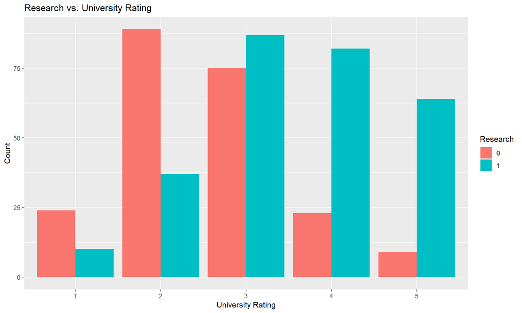

```r
# Visualize University Rating and Research
ggplot(admission, aes(x = University.Rating, fill = Research)) +
  geom_bar(position = "dodge") +
  labs(title = "Research vs. University Rating",
       x = "University Rating",
       y = "Count",
       fill = "Research")
```

### *Distribution of Chance of Admission:*

A comprehensive understanding of the distribution of the `Chance of Admission` variable is crucial for modeling. We plotted the `chance of admission` against the independent variables.

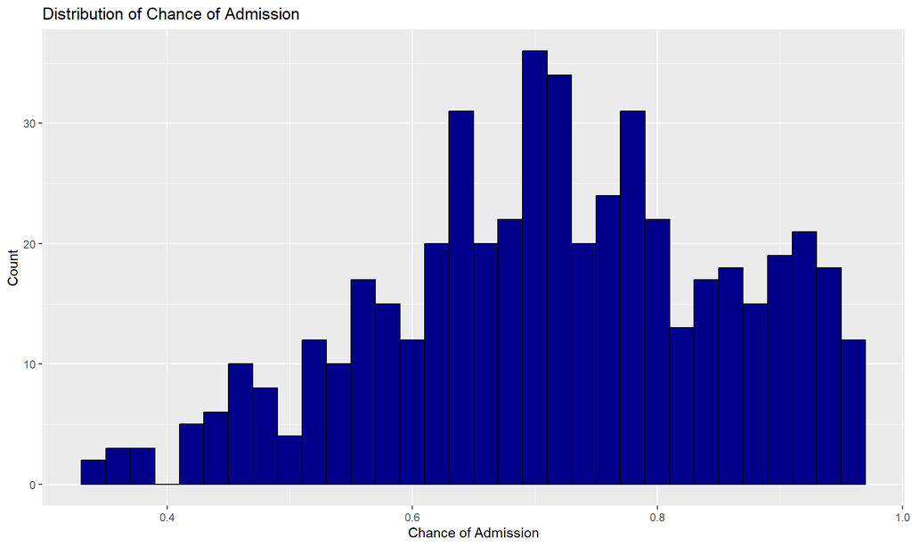

```r
# Visualize Chance of Admission
ggplot(admission, aes(x = Chance.of.Admit)) +
  geom_histogram(binwidth = 0.02, fill = "darkblue", color = "black") +
  labs(title = "Distribution of Chance of Admission",
       x = "Chance of Admission",
       y = "Count")
```

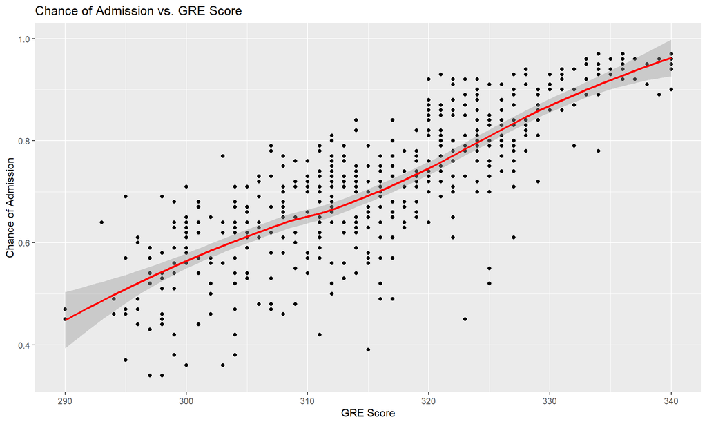

```r
# Visualize Chance of Admission vs. GRE Score with smoothing
ggplot(admission, aes(x = GRE.Score, y = Chance.of.Admit)) +
  geom_point() +
  geom_smooth(method = "loess", color = "red") +
  labs(title = "Chance of Admission vs. GRE Score",
       x = "GRE Score",
       y = "Chance of Admission")
```

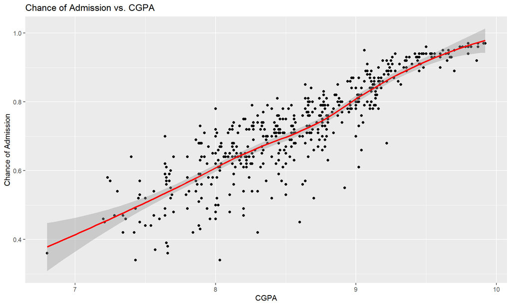

```r
# Visualize Chance of Admission vs. CGPA with smoothing
ggplot(admission, aes(x = CGPA, y = Chance.of.Admit)) +
  geom_point() +
  geom_smooth(method = "loess", color = "red") +
  labs(title = "Chance of Admission vs. CGPA",
       x = "CGPA",
       y = "Chance of Admission")
```

### *Scatter Plots for Numeric Variables:*

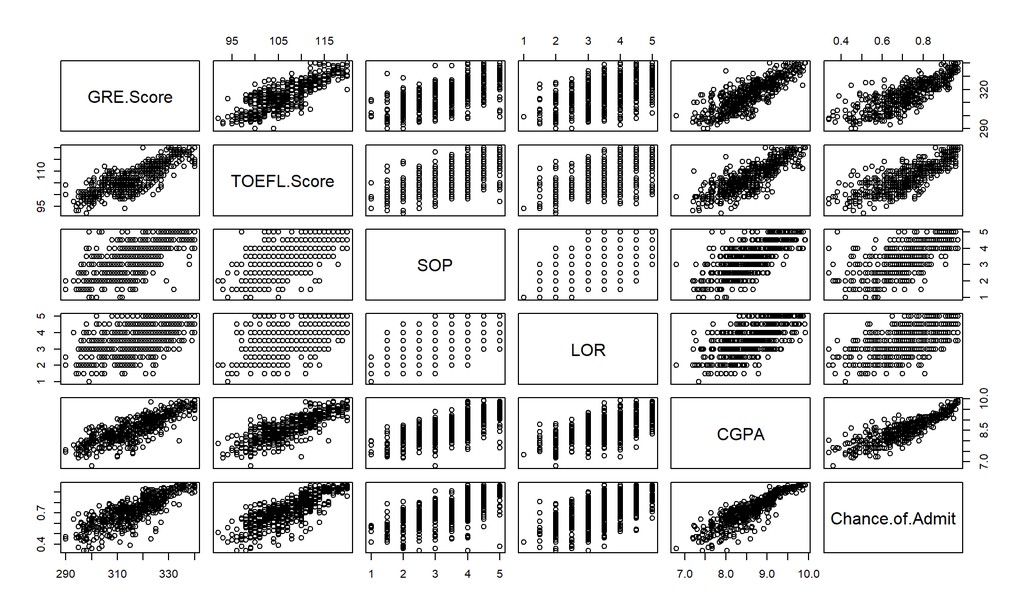

```r
# Scatter plots for numeric variables
scatter_data <- admission %>% select(GRE.Score, TOEFL.Score, SOP, LOR, CGPA, Chance.of.Admit)

pairs(scatter_data)
```

### *Correlation Analysis:*

To assess the interdependency between numeric attributes, we performed correlation analysis as highly correlated features might introduce multicollinearity in the predictive models.

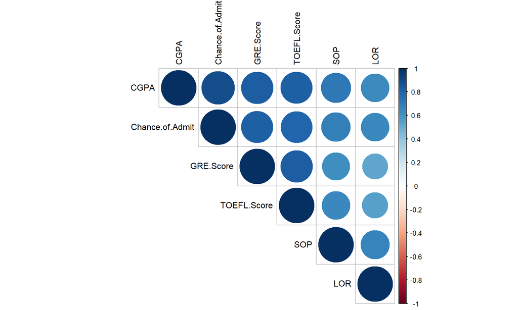

```r
# Correlation plot
correlation_matrix <- cor(scatter_data)
corrplot(correlation_matrix, type = "upper", order = "hclust", tl.col = "black")
```

By executing this robust Exploratory Data Analysis, we gained a profound understanding of the dataset’s characteristics, unveil intricate relationships between variables, and obtain valuable insights. These insights guide us in selecting appropriate features for modeling, addressing data quality concerns, and building accurate and reliable prediction models for university admission likelihood.